# PLSC 508 — Liking, Reciprocity, and Multiplicative Effects

A classroom application of additive and multiplicative effects models

Carlos Freitas Almeida

November 3, 2026

# 1 Background: cohesion and behavior in school classrooms

Van den Bos, Crone, Meuwese, and Güroğlu (2018) asked how adolescents’ network positions and classroom cohesion relate to peer-reported social behavior and generalized trust. They recruited 611 students from 22 classes in one Dutch secondary school, with a mean age of 14.8 years. They report excluding two mixed classes whose membership changed over time, leaving 496 participants (article, pp. 3 and 10).

Students nominated classmates they liked most, without a fixed nomination limit and without self-nominations. Other questions measured helping, cooperation, aggression, victimization, and perceived popularity. An economic game measured trust in unfamiliar others. The authors used **mutual liking**: an undirected edge existed only when both students nominated one another (pp. 3 and 10–11; S2 Text, item 1).

The authors measured cohesion with mutual-network density, diameter, and clusters. Denser mutual networks were associated with less antisocial behavior; larger classes with more antisocial behavior. Fewer clusters and shorter diameter were associated with greater generalized trust (pp. 5–6). At the individual level, eigenvector centrality was associated with more prosocial behavior and relational aggression and less victimization; no individual centrality measure was associated with trust (pp. 7–8; Table 3 and S4). The cross-sectional design does not identify causation (p. 9).

[Despite the title’s wording, the authors describe the direct classroom-cohesion association with prosocial behavior as a trend in the discussion (p. 9). I do not present that as an established causal effect.]

**My application keeps the directions.** I use all sixteen released students in archive group 36 to distinguish sending nominations, receiving nominations, and residual reciprocity. I model neither helping nor trust, and I am not replicating the paper’s cross-classroom behavioral regressions.

[**Question:** How are liking nominations associated with matching recorded sex and age differences, and what changes when I add multiplicative structure beyond actor tendencies and residual reciprocity? By the end, I want to be able to construct aligned network inputs, explain the two model calls, and interpret results together with their diagnostics.]

# 2 Setup and network construction

Open `W11_Dutch_Classroom.Rproj` after extracting the complete folder. Install missing packages **before** class. This document runs two rank-zero chains; it loads two rank-two chains estimated beforehand. The separate script `scripts/estimate_rank2_before_class.R` contains the rank-two reproduction calls. There are no automatic downloads, package installations, or substitutions for missing fit files.

```r
# [I check packages without installing or upgrading anything during the lesson.]
required <- c("amen", "igraph", "posterior", "knitr")
missing <- required[!vapply(required, requireNamespace, logical(1), quietly = TRUE)]
if (length(missing)) stop(paste("I need these packages before class:", paste(missing, collapse = ", ")))
library(amen)
# [These relative paths work from the extracted project, not an isolated Rmd.]
manifest <- read.csv("DATA_MANIFEST.csv", stringsAsFactors = FALSE)
stopifnot(all(file.exists(manifest$file)))
if (!identical(unname(tools::md5sum(manifest$file)), manifest$md5)) {
  stop("A supplied input differs from its recorded copy. I restore the original input rather than alter its fingerprint.")
}
reference <- readRDS("data/input_reference.rds")
nom <- read.csv("data/group36_like_nominations.csv", colClasses = "character", check.names = FALSE)
actors <- read.csv("data/group36_attributes.csv", colClasses = "character", check.names = FALSE)
ids <- nom$PPN
actors <- actors[match(ids, actors$node_id), , drop = FALSE]
stopifnot(identical(ids, actors$node_id), !anyDuplicated(ids), length(ids) == 16L)
sex <- as.integer(actors$sex)
age <- as.numeric(actors$age)
stopifnot(all(sex %in% 0:1), all(is.finite(age)))
nom[1:3, c("PPN", "group", "Q", "nomination1", "nomination2")]
```

```
##    PPN group Q nomination1 nomination2
## 1 1034    36 1        1043        1036
## 2 1035    36 1        1037        1045
## 3 1036    36 1        1034        1038
```

[The recorded render warned that `amen` was built under R 4.6.1 while this session used R 4.6.0. That warning did not stop this run. It is not a guarantee of compatibility on every computer; I retain warnings and complete the preflight rather than suppress them or require everyone to upgrade.]

The archive calls the field `sex`; the article’s Table 3 note (p. 7) and S4 Table provide the published key `0 = female`, `1 = male`. I use that documentary key for the plots, not behavioral differences as evidence of coding. [Matching recorded codes is unchanged by reversing their labels. These two categories are not an exhaustive measure of gender.]

The codebook maps `9999` to `NA`. In group 36, those entries occur after each student’s nonempty list, so I treat them as unused slots. I do not infer that a fully empty response elsewhere means observed zero nominations. One original list repeats `1042 -> 1046`; I keep the raw entries and count that ordered relationship once.

```r
# [Rows send and columns receive; unique() gives a binary nomination per pair.]
Y <- matrix(0L, length(ids), length(ids), dimnames = list(ids, ids))
listed_slots <- 0L
for (i in seq_along(ids)) {
  targets <- unname(unlist(nom[i, paste0("nomination", 1:30)], use.names = FALSE))
  targets <- targets[targets != "9999"]
  stopifnot(length(targets) > 0L, all(targets %in% ids), !any(targets == ids[i]))
  listed_slots <- listed_slots + length(targets)
  Y[i, match(unique(targets), ids)] <- 1L
}
diag(Y) <- NA_integer_  # [Self-pairs do not enter the likelihood.]
stopifnot(identical(Y, reference$Y), listed_slots == 97L)

# [A has a zero diagonal for graph calculations; Y keeps its excluded diagonal.]
A <- Y
diag(A) <- 0L
g <- igraph::graph_from_adjacency_matrix(A, mode = "directed", weighted = NULL, diag = FALSE)
stopifnot(identical(igraph::V(g)$name, ids))
```

[The released roster is complete for the selected inputs, not independently verified against an enrollment census. I selected this group for response and attribute completeness before fitting, not for coefficients or model fit.]

# 3 Describe and visualize the network

## 3.1 Size, reciprocity, and transitivity

[An actor is a student. A dyad is a pair of students; this directed matrix has 240 ordered non-self entries within 120 unordered student pairs. `Y[i, j]` records whether student i nominates student j. Out-degree counts nominations sent; in-degree counts nominations received. Directed density divides ties by n(n - 1), while mutual undirected density divides edges by n(n - 1)/2. Reciprocity is the fraction of directed nominations with a reverse nomination. Directed transitivity here is the fraction of distinct-student two-paths `i -> j -> k` with `i -> k`. I state the denominator rather than treating all transitivity definitions as equivalent (`igraph` documentation).]

```r
n_students <- igraph::vcount(g)
n_ties <- igraph::ecount(g)
out_degree <- igraph::degree(g, mode = "out", loops = FALSE)
in_degree <- igraph::degree(g, mode = "in", loops = FALSE)
reciprocated_fraction <- igraph::reciprocity(g, ignore.loops = TRUE, mode = "default")

# [A %*% A counts directed two-paths. Removing its diagonal keeps i different from k.]
two_paths <- A %*% A
diag(two_paths) <- 0
n_two_paths <- sum(two_paths)
n_closed_paths <- sum(two_paths * A)
directed_transitivity <- n_closed_paths / n_two_paths

# [This separate undirected graph follows the paper's mutual-tie rule.]
M <- A * t(A)
g_mutual <- igraph::graph_from_adjacency_matrix(M, mode = "undirected", weighted = NULL, diag = FALSE)
mutual_pairs <- igraph::ecount(g_mutual)
mutual_density <- igraph::edge_density(g_mutual, loops = FALSE)
mutual_transitivity <- igraph::transitivity(g_mutual, type = "global")
descriptives <- data.frame(
  measure = c("Students", "Directed ties", "Directed density", "Reciprocated fraction of ties",
              "Directed transitivity: closed two-path fraction", "Mutual undirected edges",
              "Mutual-network density", "Mutual-network global transitivity"),
  value = c(n_students, n_ties, igraph::edge_density(g, loops = FALSE), reciprocated_fraction,
            directed_transitivity, mutual_pairs, mutual_density, mutual_transitivity))
knitr::kable(descriptives, digits = 3, row.names = FALSE)
```

| measure | value |
| --- | --- |
| Students | 16.000 |
| Directed ties | 96.000 |
| Directed density | 0.400 |
| Reciprocated fraction of ties | 0.583 |
| Directed transitivity: closed two-path fraction | 0.643 |
| Mutual undirected edges | 28.000 |
| Mutual-network density | 0.233 |
| Mutual-network global transitivity | 0.552 |

[There are 96 directed nominations and 28 mutual pairs. Thus 56 of the 96 nominations are reciprocated: 58.3%. Of 485 directed two-paths, 312 are transitively closed. Neither number is the model’s residual `rho`. The mutual graph’s density is lower because it excludes one-way liking.]

For `g_mutual`, global transitivity is **three times the number of triangles divided by the number of connected triples**, where a triple has two mutual edges sharing a student (`igraph::transitivity`). It is not AME’s centered, standardized `trans.dep`, which appears later.

## 3.2 Degree distributions

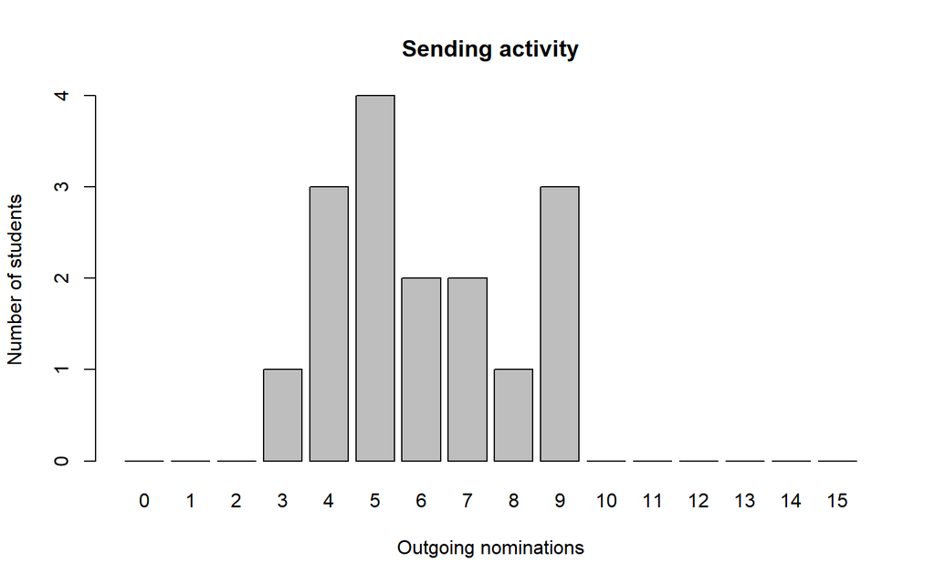

```r
barplot(table(factor(out_degree, levels = 0:(n_students - 1))),
  xlab = "Outgoing nominations", ylab = "Number of students", main = "Sending activity")
```

[Outgoing degree counts how many classmates each student nominates; it is not a measure of helpfulness.]

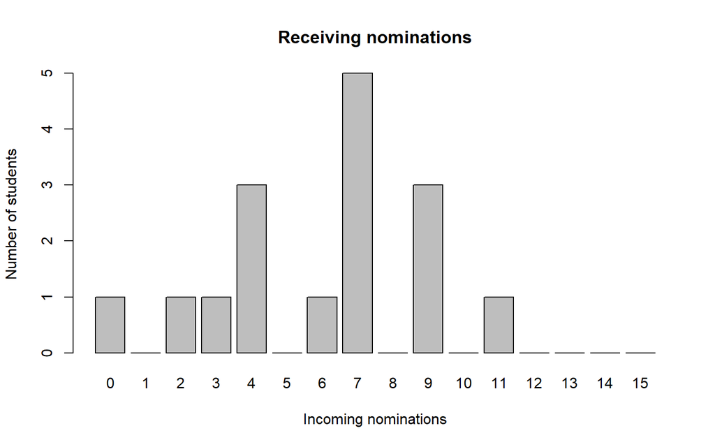

```r
barplot(table(factor(in_degree, levels = 0:(n_students - 1))),
  xlab = "Incoming nominations", ylab = "Number of students", main = "Receiving nominations")
```

[Incoming degree counts how often a student is nominated. One student receives no nominations but sends nine, so that student is not an isolate. This is liking popularity, not the study’s separately measured perceived-popularity item.]

## 3.3 Sociogram

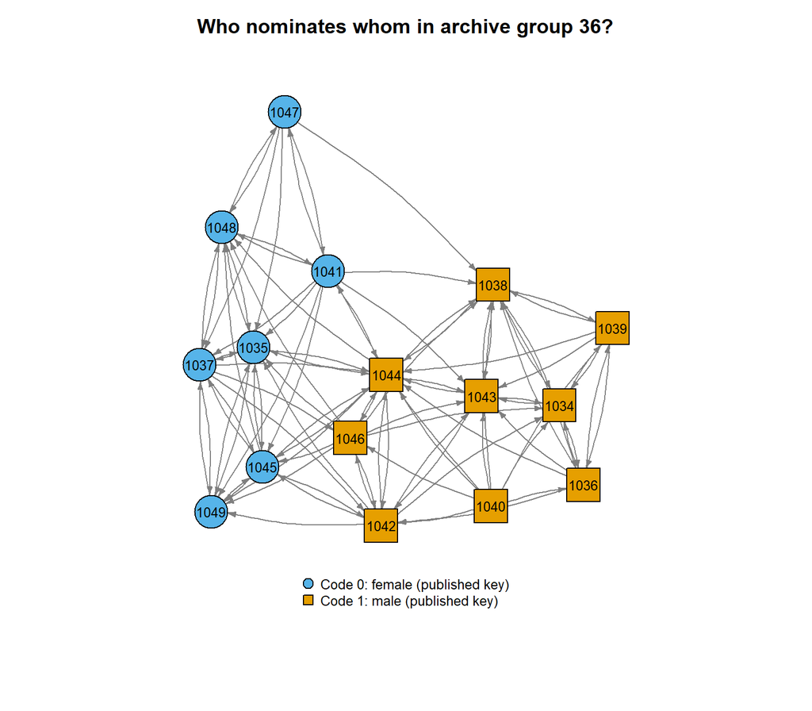

```r
# [I keep the layout seed and algorithm. Only the display and its key change.]
sex_colors <- c("#56B4E9", "#E69F00")
sex_shapes <- c("circle", "square")
node_colors <- sex_colors[sex + 1L]
key_text <- c("Code 0: female (published key)", "Code 1: male (published key)")
set.seed(50836)
layout_xy <- igraph::layout_with_fr(g)
old_par <- par(mar = c(.5, .5, 2.5, .5))
# [Rescaled nodes occupy -1 to 1; the lower strip is reserved for the key.]
plot(g, layout = layout_xy, rescale = TRUE, ylim = c(-1.65, 1.1),
     vertex.color = node_colors, vertex.shape = sex_shapes[sex + 1L],
     vertex.size = 16, vertex.label = ids, vertex.label.family = "sans",
     vertex.label.cex = .8, vertex.label.color = "black",
     edge.arrow.size = .4, edge.curved = .12, edge.color = "grey50",
     main = "Who nominates whom in archive group 36?")
legend(x = 0, y = -1.32, xjust = .5, yjust = .5, legend = key_text,
       pch = c(21, 22), pt.bg = sex_colors, pt.cex = 1.4, bty = "n", cex = .8)
```

```r
par(old_par)
```

[Arrows preserve all 96 nominations. Layout positions are a visual arrangement, not a measured social distance or fitted latent space. Color and shape show recorded categories; apparent grouping does not establish a causal preference.]

# 4 Model the nominations in steps

## 4.1 Step 1: Define the predictors and model

```r
Xdyad <- array(0, dim = c(length(ids), length(ids), 2L),
  dimnames = list(ids, ids, c("same_recorded_sex", "age_absdiff_years")))
Xdyad[, , "same_recorded_sex"] <- 1 * outer(sex, sex, "==")
Xdyad[, , "age_absdiff_years"] <- abs(outer(age, age, "-"))
stopifnot(identical(Xdyad, reference$Xdyad))
dim(Xdyad)
```

```
## [1] 16 16  2
```

[The first layer compares recorded categories; the second measures age difference in years. Row and column order is identical to `Y`. `Xrow = NULL` and `Xcol = NULL` omit measured sender/receiver predictors, not their latent random effects.]

For a binary probit model, `Y[i,j] = 1` when the latent propensity is positive:

**z<sub>ij</sub> = β<sub>0</sub> + β<sub>s</sub>same<sub>ij</sub> + β<sub>a</sub>|age<sub>i</sub> − age<sub>j</sub>| + a<sub>i</sub> + b<sub>j</sub> + u<sub>i</sub><sup>T</sup>v<sub>j</sub> + ε<sub>ij</sub>.**

| Component | Meaning in this classroom | Code/result |
| --- | --- | --- |
| Measured coefficients | Conditional association with matching sex code and age difference | `Xdyad`, `BETA` |
| Sender effect | Residual tendency to nominate classmates | `rvar`, `APM`, variance `va` |
| Receiver effect | Residual tendency to receive nominations | `cvar`, `BPM`, variance `vb` |
| Sender–receiver covariance | Association between the same student’s two tendencies | `cab` |
| Residual reciprocity | Correlation between opposite-direction latent errors within a pair | `dcor`, `rho` |
| Multiplicative contribution | Higher-order patterns beyond the predictors and additive/dyadic terms | `R`, `U`, `V`, `UVPM` |

INA §10.5 calls AME a latent-factor model. Week 10 introduced Euclidean distance (slide 4) and a bilinear inner-product representation (slides 20–21). These calls use separate sender/receiver vectors, not a Euclidean-distance term. Additive and dyadic components represent actor heterogeneity and reciprocity; multiplicative effects can represent higher-order patterns (Dorff et al., 2020, pp. 484–485; Minhas et al., 2019; Hoff, 2021).

[The readings may place a diagonal scaling matrix between factors; the installed directed implementation computes `U %*% t(V)`. That scaling can be absorbed algebraically into unrestricted vectors without establishing identical priors. `R = 0` removes only the multiplicative part. `R = 2` can represent shared-partner and triadic patterns but does not guarantee transitivity or identify a trait. `R` is the multiplicative dimension, not a distance dimension or mixture-group count. The residual variance is fixed at one for probit identification. Given model parameters and latent effects, different unordered residual pairs are independent, but opposite directions within a pair may correlate through `rho`. `prior = list()` retains the package’s default, data-calibrated priors.]

## 4.2 Step 2: Fit two rank-zero chains live

[These calls run both when I execute the chunk and when I knit the lesson. In the October 29 run they took 108.63 and 105.84 seconds, about 3.57 minutes combined; the table prints the times for the current run. Other computers may differ. A chain is a sequence of simulated parameter values. I discard the first 10,000 iterations (`burn`), run 50,000 more (`nscan`), and retain every 25th (`odens`): 2,000 saved draws per chain. Saving less often does not make those draws independent. I keep the checked settings (`amen::ame`, version 1.4.5).]

```r
RNGkind("Mersenne-Twister", "Inversion", "Rejection")
seeds0 <- c(50836101L, 50836102L)
r0_execution <- "estimated_in_this_session"
R0 <- vector("list", 2L)
runtime0 <- numeric(2L)
for (j in seq_along(seeds0)) {
  cat("I fit rank-zero chain", j, "with seed", seeds0[j], "\n")
  runtime0[j] <- system.time({
    R0[[j]] <- amen::ame(
      Y = Y, Xdyad = Xdyad, Xrow = NULL, Xcol = NULL,
      family = "bin", R = 0, rvar = TRUE, cvar = TRUE, dcor = TRUE,
      intercept = TRUE, symmetric = FALSE, prior = list(),
      seed = seeds0[j], burn = 10000, nscan = 50000, odens = 25,
      plot = FALSE, print = FALSE, gof = TRUE
    )
  })[["elapsed"]]
}
```

```
## I fit rank-zero chain 1 with seed 50836101
## I fit rank-zero chain 2 with seed 50836102
```

```r
data.frame(chain = 1:2, seed = seeds0, seconds = runtime0,
           retained = vapply(R0, function(f) nrow(f$BETA), integer(1)))
```

```
##   chain     seed seconds retained
## 1     1 50836101  115.00     2000
## 2     2 50836102  132.09     2000
```

[These two chains estimate the same model with different random-number seeds. They are not two different classrooms. The package uses data-based starts; different seeds are not deliberately dispersed starting values. A chain count alone does not establish adequate sampling.]

## 4.3 Step 3: Load two rank-two chains estimated beforehand

```r
# [These fits already exist. This chunk does not run rank-two estimation.]
preestimated <- readRDS("data/rank2_preestimated.rds")
stopifnot(identical(preestimated$inputs$Y, Y),
          identical(preestimated$inputs$Xdyad, Xdyad), length(preestimated$fits) == 2L)
R2 <- preestimated$fits
stopifnot(all(vapply(R2, function(f) nrow(f$BETA), integer(1)) == 8000L))
data.frame(chain = 1:2, seed = preestimated$seeds,
           retained = vapply(R2, function(f) nrow(f$BETA), integer(1)))
```

```
##   chain     seed retained
## 1     1 50836301     8000
## 2     2 50836302     8000
```

I use the first two numbered chains from the longer rank-two run, not a pair chosen for attractive results. Each used 10,000 burn-in iterations and 200,000 later iterations, saving every 25th. The four-chain background checks remain in my authoring records; every table below uses **two chains per model**. The rank-zero and rank-two budgets differ, but their data and model components other than multiplicative rank are the same.

## 4.4 Step 4: Check sampling and summarize the estimates

```r
# [Each column of x is a chain; I do not concatenate chains before calculating R-hat.]
summarize_model <- function(fits, model) {
  parameters <- c(colnames(fits[[1]]$BETA), "va", "vb", "cab", "rho")
  rows <- lapply(parameters, function(p) {
    x <- sapply(fits, function(f) {
      if (p %in% colnames(f$BETA)) f$BETA[, p] else f$VC[, p]
    })
    data.frame(model = model, parameter = p, mean = mean(x),
      lower = unname(quantile(x, .025)), upper = unname(quantile(x, .975)),
      rhat = posterior::rhat(x), bulk_ess = posterior::ess_bulk(x),
      tail_ess = posterior::ess_tail(x), mcse_over_sd = posterior::mcse_mean(x) / sd(c(x)))
  })
  do.call(rbind, rows)
}
summary_table <- rbind(summarize_model(R0, "R = 0"), summarize_model(R2, "R = 2"))
stopifnot(all(vapply(c(R0, R2), function(f) all(f$VC[, "ve"] == 1), logical(1))))
knitr::kable(summary_table[, c("model", "parameter", "rhat", "bulk_ess", "tail_ess", "mcse_over_sd")],
             digits = c(0, 0, 4, 0, 0, 3), row.names = FALSE)
```

| model | parameter | rhat | bulk_ess | tail_ess | mcse_over_sd |
| --- | --- | --- | --- | --- | --- |
| R = 0 | intercept | 1.0000 | 4072 | 3844 | 0.016 |
| R = 0 | same_recorded_sex.dyad | 0.9998 | 3761 | 3765 | 0.016 |
| R = 0 | age_absdiff_years.dyad | 1.0002 | 4062 | 3751 | 0.016 |
| R = 0 | va | 0.9998 | 3895 | 3476 | 0.016 |
| R = 0 | vb | 1.0004 | 3338 | 3594 | 0.017 |
| R = 0 | cab | 1.0001 | 4035 | 3687 | 0.016 |
| R = 0 | rho | 1.0037 | 625 | 595 | 0.036 |
| R = 2 | intercept | 1.0001 | 2891 | 5262 | 0.019 |
| R = 2 | same_recorded_sex.dyad | 1.0001 | 1656 | 2682 | 0.025 |
| R = 2 | age_absdiff_years.dyad | 1.0001 | 10007 | 12663 | 0.010 |
| R = 2 | va | 0.9999 | 4444 | 7411 | 0.016 |
| R = 2 | vb | 1.0004 | 2627 | 5074 | 0.021 |
| R = 2 | cab | 1.0000 | 2867 | 4660 | 0.020 |
| R = 2 | rho | 1.0031 | 620 | 1002 | 0.034 |

```r
flag <- with(summary_table, !is.finite(rhat) | rhat >= 1.01 | bulk_ess < 400 |
                              tail_ess < 400 | mcse_over_sd > .05)
if (any(flag)) warning("I inspect the flagged summaries; I do not change the pair or discard a chain.")
```

[**Sampling check:** R-hat near one and sufficiently large effective sample sizes are reassuring, but do not prove convergence. These diagnostics concern the saved parameter draws, not the number of students. `mcse_over_sd` measures simulation error in a posterior mean relative to its posterior standard deviation; I exclude `ve` only after verifying that it is fixed at one.]

```r
coefficient_rows <- summary_table$parameter %in% colnames(R0[[1]]$BETA)
knitr::kable(summary_table[coefficient_rows, c("model", "parameter", "mean", "lower", "upper")],
             digits = 3, row.names = FALSE, caption = "Probit coefficients and central 95% credible intervals")
```

Probit coefficients and central 95% credible intervals

| model | parameter | mean | lower | upper |
| --- | --- | --- | --- | --- |
| R = 0 | intercept | -1.130 | -1.732 | -0.524 |
| R = 0 | same_recorded_sex.dyad | 1.677 | 1.217 | 2.162 |
| R = 0 | age_absdiff_years.dyad | -0.159 | -0.977 | 0.643 |
| R = 2 | intercept | -2.198 | -3.296 | -1.263 |
| R = 2 | same_recorded_sex.dyad | 3.274 | 2.304 | 4.482 |
| R = 2 | age_absdiff_years.dyad | -0.289 | -1.456 | 0.853 |

```r
# [This small lookup keeps the narrative tied to the actual results above.]
value <- function(model, parameter, column = "mean") {
  summary_table[summary_table$model == model & summary_table$parameter == parameter, column]
}
interval_text <- function(model, parameter) {
  paste0("[", sprintf("%.3f", value(model, parameter, "lower")), ", ",
         sprintf("%.3f", value(model, parameter, "upper")), "]")
}
```

[**Matching recorded sex:** The coefficients are 1.677 for R0 and 3.274 for R2. Both indicate a positive conditional association between matching recorded sex codes and liking nominations, not a percentage-point effect or proof of a causal preference.]

[**Age difference:** The estimated coefficients are -0.159 for R0 and -0.289 for R2. Both credible intervals include zero, so the association remains uncertain in this classroom. These are probit coefficients, not odds ratios.]

```r
variance_rows <- summary_table$parameter %in% c("va", "vb", "cab", "rho")
knitr::kable(summary_table[variance_rows, c("model", "parameter", "mean", "lower", "upper")],
             digits = 3, row.names = FALSE, caption = "Sender/receiver components and residual reciprocity")
```

Sender/receiver components and residual reciprocity

| model | parameter | mean | lower | upper |
| --- | --- | --- | --- | --- |
| R = 0 | va | 0.203 | 0.071 | 0.466 |
| R = 0 | vb | 0.483 | 0.165 | 1.087 |
| R = 0 | cab | -0.113 | -0.374 | 0.078 |
| R = 0 | rho | 0.671 | 0.284 | 0.944 |
| R = 2 | va | 0.512 | 0.136 | 1.389 |
| R = 2 | vb | 1.185 | 0.319 | 3.186 |
| R = 2 | cab | -0.515 | -1.530 | -0.028 |
| R = 2 | rho | 0.648 | -0.335 | 0.992 |

[**Activity and popularity:** `va` and `vb` measure remaining differences in students’ latent tendencies to send and receive nominations. For R2, their posterior means are 0.512 and 1.185. These are not observed degree variances.]

[**Covariance:** `cab` describes the association between the same student’s latent sending and receiving tendencies. The R2 interval is [-1.530, -0.028], indicating a negative conditional association in this model, not a personal trait or causal mechanism.]

[**Residual reciprocity:** `rho` measures the remaining association between opposite-direction latent errors, not the observed reciprocated-tie fraction. Its R2 interval is [-0.335, 0.992], which includes zero. The installed sampler also has a boundary at 0.995; the model’s residual reciprocity remains uncertain.]

## 4.5 Step 5: Visualize the multiplicative effects

[Each row of `U` is a sending profile and each row of `V` a receiving profile. I show the **first numbered R2 chain**. The returned matrices form an SVD-based rank-two approximation to its mean product `UVPM`, not complete factor-draw histories. I do not average unaligned coordinates across chains or identify an arbitrary axis with a measured student trait.]

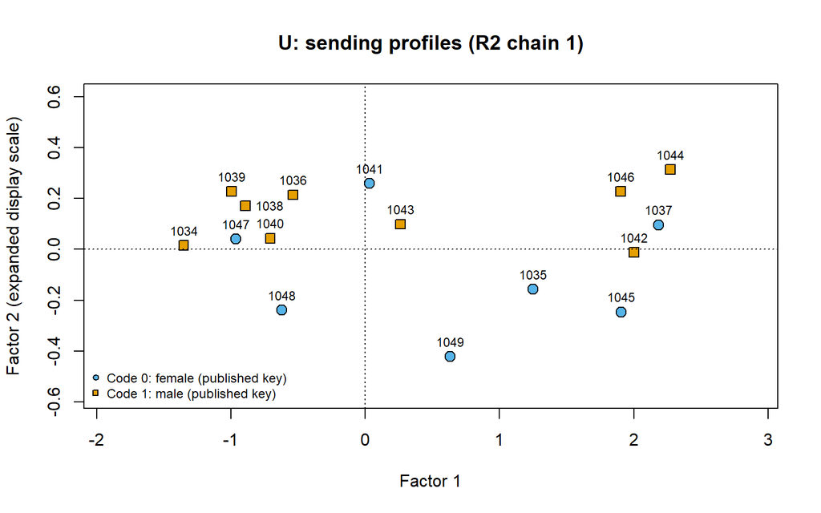

```r
U <- R2[[1]]$U
V <- R2[[1]]$V
stopifnot(ncol(U) == 2L, ncol(V) == 2L,
          identical(rownames(U), ids), identical(rownames(V), ids))
xlim <- grDevices::extendrange(c(U[, 1], V[, 1]), f = .12)
ylim <- grDevices::extendrange(c(U[, 2], V[, 2]), f = .18)
sex_pch <- c(21, 22)[sex + 1L]
# [Only text placement changes; I do not move the fitted coordinates.]
u_label_pos <- setNames(rep(3, length(ids)), ids)
u_label_pos["1038"] <- 4
plot(U[, 1], U[, 2], pch = sex_pch, bg = node_colors, cex = 1.4,
     xlim = xlim, ylim = ylim, xlab = "Factor 1",
     ylab = "Factor 2 (expanded display scale)", main = "U: sending profiles (R2 chain 1)")
abline(h = 0, v = 0, lty = 3)
text(U[, 1], U[, 2], labels = ids, pos = u_label_pos, cex = .75)
legend("bottomleft", legend = key_text, pch = c(21, 22), pt.bg = sex_colors,
       bty = "n", cex = .75)
```

[The contribution in this rank-two display is the **sum** u<sub>i1</sub>v<sub>j1</sub> + u<sub>i2</sub>v<sub>j2</sub>. Same signs make the first product positive; opposite signs make it negative. The second product can reverse the total, especially near zero on Factor 1. The sender–receiver contribution is not their Euclidean distance.]

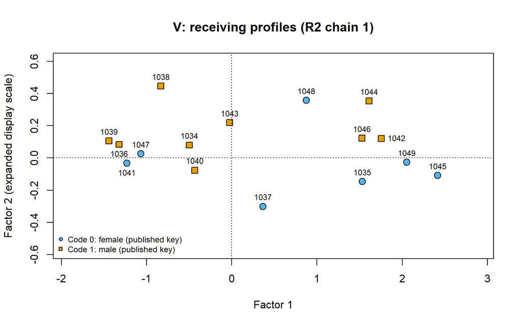

```r
v_label_pos <- setNames(rep(3, length(ids)), ids)
v_label_pos[c("1036", "1041")] <- 1
v_label_pos["1042"] <- 4
plot(V[, 1], V[, 2], pch = sex_pch, bg = node_colors, cex = 1.4,
     xlim = xlim, ylim = ylim, xlab = "Factor 1",
     ylab = "Factor 2 (expanded display scale)", main = "V: receiving profiles (R2 chain 1)")
abline(h = 0, v = 0, lty = 3)
text(V[, 1], V[, 2], labels = ids, pos = v_label_pos, cex = .75)
legend("bottomleft", legend = key_text, pch = c(21, 22), pt.bg = sex_colors,
       bty = "n", cex = .75)
```

[**Factor interpretation:** In this chain’s mean-product summary, the first singular value is approximately 28.93 and the second approximately 0.69, so the first component dominates this displayed summary. This does not mean the fitted model is rank one or that the axes identify measured personality traits. The factor plots represent model-based sending and receiving patterns, not the sociogram’s layout positions.]

## 4.6 Step 6: Check all five network features

The default `amen` plot shows parameter traces and five predictive histograms. I retain the unchanged package method and show the first numbered chain of each model; the numerical table uses both chains. These single-chain panels do not replace the two-chain diagnostics.

[Trace colors distinguish **parameters within one chain**, not different chains. The VC panel follows `va`, `cab`, `vb`, `rho`, `ve`; the BETA panel follows the intercept, matching-code coefficient, and age-difference coefficient. Colored horizontal lines mark that chain’s parameter medians. The gray zero line is in the BETA panel. In each histogram the red vertical line is the observed statistic; the bars describe saved replicated-network statistics and use a density scale with omitted vertical-axis ticks (`amen::plot.ame`, version 1.4.5).]

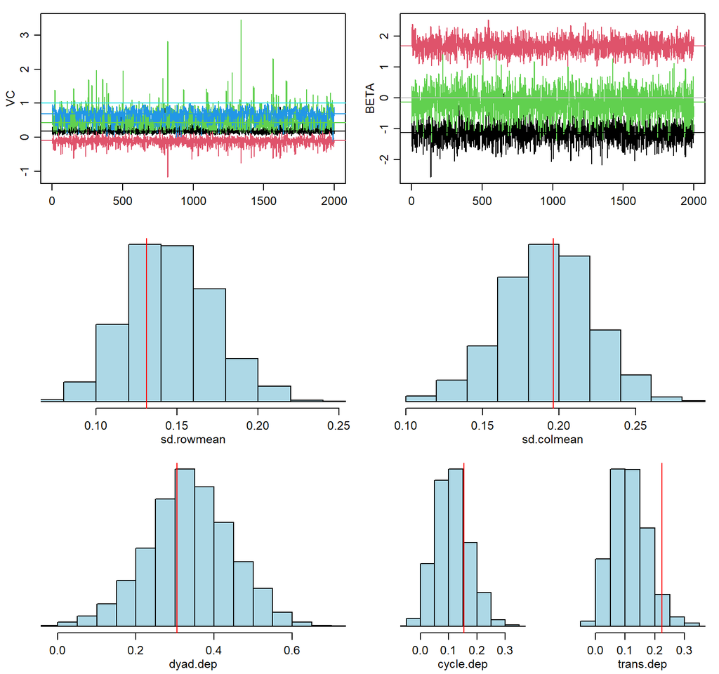

```r
plot(R0[[1]])
```

[For each histogram, locate the observed line and compare it with the whole replicated distribution, not only with its center.]

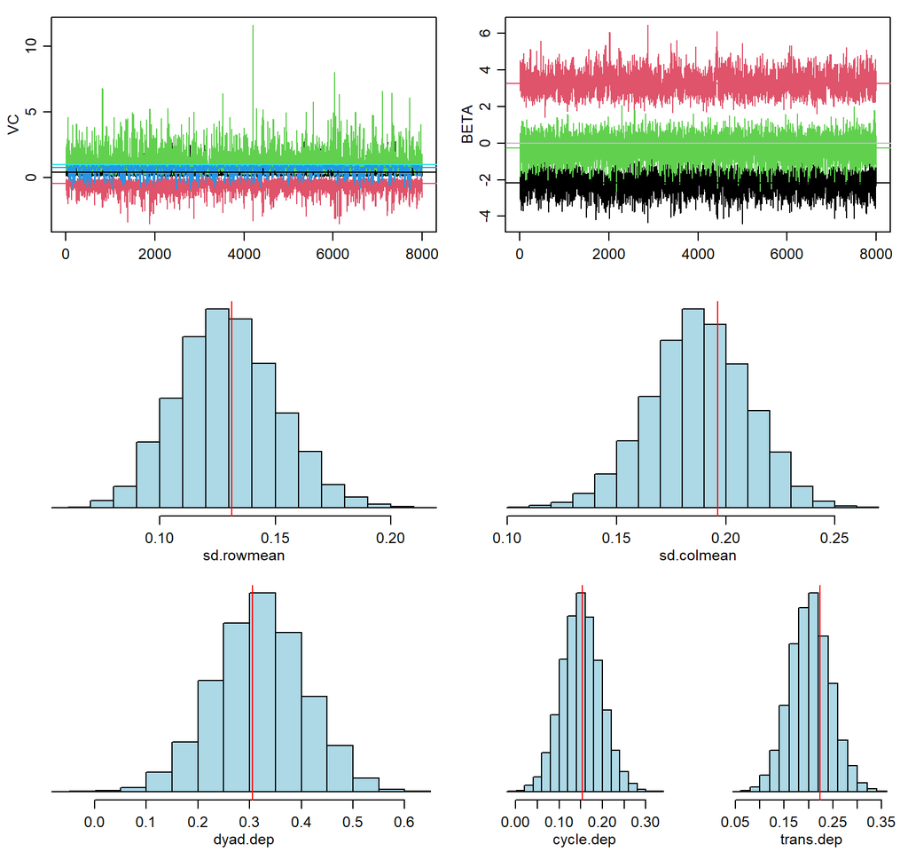

| GOF label | Network feature |
| --- | --- |
| `sd.rowmean` | Standard deviation of outgoing nomination rates across students |
| `sd.colmean` | Standard deviation of incoming nomination rates across students |
| `dyad.dep` | Observed opposite-direction association; not residual `rho` |
| `cycle.dep` | Centered, standardized directed-cycle dependence |
| `trans.dep` | Centered, standardized transitive dependence; not the descriptive closure ratio |

```r
plot(R2[[1]])
```

[The central 95% **predictive interval** contains the middle 95% of a statistic across the saved replicated networks. It concerns replicated data, whereas a credible interval concerns a parameter. The installed implementation returns five GOF statistics even though the brief help description mentions four.]

```r
predictive_table <- function(fits, label) {
  observed <- fits[[1]]$GOF[1, ]
  stopifnot(isTRUE(all.equal(observed, fits[[2]]$GOF[1, ])))
  # [Row 1 is observed; I exclude it from all replicated-draw calculations.]
  draws <- do.call(rbind, lapply(fits, function(f) f$GOF[-1, , drop = FALSE]))
  intervals <- apply(draws, 2, quantile, probs = c(.025, .975))
  share <- colMeans(sweep(draws, 2, observed, ">="))
  data.frame(model = label, statistic = names(observed), observed = unname(observed),
    replicated_mean = colMeans(draws), lower = intervals[1, ], upper = intervals[2, ],
    rep_ge_obs = unname(share), row.names = NULL)
}
gof_table <- rbind(predictive_table(R0, "R = 0"), predictive_table(R2, "R = 2"))
knitr::kable(gof_table, digits = 3, row.names = FALSE,
  caption = "Both chains: observed values, replicated means, central 95% intervals, and replicated shares at least as large as observed")
```

Both chains: observed values, replicated means, central 95% intervals, and replicated shares at least as large as observed

| model | statistic | observed | replicated_mean | lower | upper | rep_ge_obs |
| --- | --- | --- | --- | --- | --- | --- |
| R = 0 | sd.rowmean | 0.131 | 0.146 | 0.097 | 0.202 | 0.700 |
| R = 0 | sd.colmean | 0.196 | 0.192 | 0.131 | 0.249 | 0.450 |
| R = 0 | dyad.dep | 0.306 | 0.339 | 0.111 | 0.549 | 0.631 |
| R = 0 | cycle.dep | 0.154 | 0.113 | 0.009 | 0.240 | 0.236 |
| R = 0 | trans.dep | 0.224 | 0.116 | 0.015 | 0.250 | 0.055 |
| R = 2 | sd.rowmean | 0.131 | 0.130 | 0.089 | 0.175 | 0.462 |
| R = 2 | sd.colmean | 0.196 | 0.188 | 0.142 | 0.231 | 0.353 |
| R = 2 | dyad.dep | 0.306 | 0.319 | 0.143 | 0.491 | 0.568 |
| R = 2 | cycle.dep | 0.154 | 0.151 | 0.063 | 0.242 | 0.478 |
| R = 2 | trans.dep | 0.224 | 0.203 | 0.122 | 0.286 | 0.308 |

```r
gof_value <- function(model, statistic, column) {
  gof_table[gof_table$model == model & gof_table$statistic == statistic, column]
}
```

[**Predictive fit:** All five observed statistics fall within both models’ central 95% predictive intervals, but coverage alone does not establish good fit. For `trans.dep`, approximately 5.5% of R0 replications and 30.8% of R2 replications reach the observed value, suggesting that R2 better reproduces this particular feature. R2 is not closer for every feature; these are in-sample descriptive comparisons, not causal findings or formal model-selection results.]

# 5 Connect the results to classroom cohesion

Van den Bos et al. (2018, p. 3) measure cohesion using mutual liking, whereas my directed network also retains one-way nominations.

[**What these results suggest about cohesion:** In group 36, 56 of 96 directed nominations are reciprocated (58.3%), and 312 of 485 directed two-paths are closed (64.3%), suggesting substantial mutuality and local closure among the recorded classroom ties. Requiring mutual nominations reduces density from 0.400 to 0.233, showing that many nominations are one-way, including the nine sent by student 1040. These patterns are consistent with some local cohesion, but they do not establish how this classroom compares with other classrooms or whether cohesion causes helping, trust, or supportive relationships.]

# 6 Try it yourself

[**Two-minute exercise:** Choose one item below; do not fit another model. The remaining items are practice after the presentation.]

1. Calculate the density of `g_mutual` and explain why it differs from directed density even though the student roster is unchanged.
2. Find the rank-two age-difference and `rho` intervals. Write one sentence that respects the uncertainty in each.
3. From `gof_table`, identify one feature whose replicated mean is closer to the observation under each model. Explain why that is not a causal conclusion.

```r
# [I type my answer below. These hints are comments, not executed answers.]
# [1. Apply igraph::edge_density() to g_mutual.]
# [2. Inspect model, parameter, lower, and upper in summary_table.]
# [3. Compare abs(replicated_mean - observed) in gof_table.]
```

# 7 References and provenance

- van den Bos, W., Crone, E. A., Meuwese, R., & Güroğlu, B. (2018). Social network cohesion in school classes promotes prosocial behavior. *PLOS ONE, 13*(4), e0194656. https://doi.org/10.1371/journal.pone.0194656. S2 Text provides nomination items; Table 3 and S4 document the regression coding key.
- van den Bos, W., Crone, E., & Güroğlu, B. *Peer Group Cohesion and Prosocial Behavior* [OSF project]. https://osf.io/vucwf/. Recorded license: CC BY 4.0, https://creativecommons.org/licenses/by/4.0/. I select group 36 and Q = 1, count a duplicate once, exclude self-pairs, and retain directions rather than using the paper’s mutual-only network as the model outcome.
- Cranmer, S. J., Desmarais, B. A., & Morgan, J. W. (2021). *Inferential Network Analysis*, Chapter 10, “Extending the Latent Space Model,” §10.5. Cambridge University Press.
- Desmarais, B. A. (2026). *Latent Space Models* [Week 10 lecture slides]. PLSC 508, Pennsylvania State University, slides 4 and 20–21.
- Dorff, C., Gallop, M., & Minhas, S. (2020). Networks of violence: Predicting conflict in Nigeria. *The Journal of Politics, 82*(2), 476–493. https://doi.org/10.1086/706459, pp. 484–485 for the model components.
- Hoff, P. D. (2021). Additive and multiplicative effects network models. *Statistical Science, 36*(1), 34–50. https://doi.org/10.1214/19-STS757.
- Minhas, S., Hoff, P. D., & Ward, M. D. (2019). Inferential approaches for network analysis: AMEN for latent factor models. *Political Analysis, 27*(2), 208–222. https://doi.org/10.1017/pan.2018.50.
- Hoff, P., Fosdick, B., & Volfovsky, A. (2024). *amen*, version 1.4.5. https://doi.org/10.32614/CRAN.package.amen. Function documentation: https://pdhoff.github.io/amen/reference/ame.html and https://pdhoff.github.io/amen/reference/plot.ame.html.
- The igraph development team. *igraph: Network Analysis and Visualization*, version 2.3.3 [R package used in the recorded classroom run]. https://CRAN.R-project.org/package=igraph. Definitions and plotting: https://r.igraph.org/reference/reciprocity.html, https://r.igraph.org/reference/transitivity.html, and https://r.igraph.org/reference/plot.igraph.html. Global transitivity ignores direction; I use it only on the explicit mutual undirected graph.
- Bürkner, P.-C., Gabry, J., Kay, M., & Vehtari, A. (2026). *posterior: Tools for Working with Posterior Distributions*, version 1.7.0 [R package]. https://mc-stan.org/posterior/. Diagnostic definitions: https://mc-stan.org/posterior/reference/rhat.html, https://mc-stan.org/posterior/reference/ess_bulk.html, https://mc-stan.org/posterior/reference/ess_tail.html, and https://mc-stan.org/posterior/reference/mcse_mean.html.
- Vehtari, A., Gelman, A., Simpson, D., Carpenter, B., & Bürkner, P.-C. (2021). Rank-normalization, folding, and localization: An improved R-hat for assessing convergence of MCMC (with discussion). *Bayesian Analysis, 16*(2), 667–718. https://doi.org/10.1214/20-BA1221.

[The public release contains 584 sender IDs in 21 archive groups and 506 attribute records, differing from the article’s reported recruitment/exclusion counts. I do not equate group 36 with a numbered S6 Table row or claim to have recovered a complete enrollment census. The original records and four-chain checks remain in my separate authoring archive.]

## 7.1 Contribution and tool disclosure

I used ChatGPT to help troubleshoot R code and revise explanations. I ran the data checks, model estimation, diagnostics, and document rendering in RStudio on my laptop. I retained the original data, scripts, settings, fitted objects, and execution records for verification. I am responsible for checking the suggestions I use and for the submitted work and its interpretation.

# 8 Session record

```r
dir.create("outputs", showWarnings = FALSE)
run_stamp <- paste0(format(Sys.time(), "%Y%m%d_%H%M%S"), "_", Sys.getpid())
run_record <- file.path("outputs", paste0("classroom_run_", run_stamp, ".rds"))
saveRDS(list(R0 = R0, R0_execution = r0_execution, R0_seeds = seeds0, R0_runtime = runtime0,
             R2_seeds = preestimated$seeds,
             R2_file_md5 = unname(tools::md5sum("data/rank2_preestimated.rds")),
             inputs = list(Y = Y, Xdyad = Xdyad), descriptives = descriptives,
             summary = summary_table, gof = gof_table,
             source_md5 = unname(tools::md5sum("Week11_Dutch_AME_Class.Rmd")),
             session = capture.output(sessionInfo())), run_record)
cat("I saved my executed classroom record:", run_record, "\n")
```

```
## I saved my executed classroom record: outputs/classroom_run_20261030_203908_36312.rds
```